# Project Report

LCJJ

Author

Charlie Lovett, Jacob Muriel, Lainey Neild, and Jack Troxel

Published

May 23, 2023

Abstract

*This project focuses on the development of a model to predict salaries in STEM fields. In this project, the optimization metric used was Mean Absolute Error. An MAE on testing data of ~47,000 was achieved using the following models and ensembling techniques- Ridge, Lasso, Random Forest, AdaBoost, Gradient Boosting, and XGBoost. Based on this model, stakeholders including students and employers can more accurately predict salaries to correctly value work and avoid overcompensating employees*.

## 1 Background / Motivation

All four of us are current college students that will soon be entering the professional world. Many of us are planning to pursue careers in various STEM fields such as software development or data science. With this in mind, we wanted to create a model that can help to predict the salaries of the people that work in these fields. Through this project, we wanted to develop a model that we could one day use to predict what our salaries should be.

## 2 Problem statement

Through this project, we will attempt to predict the salaries for employees that work in STEM fields. As we are predicting salaries, the response observed in this project is a continuous variable—their annunal salary in USD. We will assess our model accuracy using MAE. We have selected this metric instead of RMSE as there is no inherit risk or disadvantage in incorrectly predicting observations by a large margin.

## 3 Data sources

We will be using a data source comprised of salary data for employees in STEM fields. This dataset was found on Kaggle and contains data scraped from a salary collecting website (levels.fyi). The data can be found [here](https://www.kaggle.com/datasets/jackogozaly/data-science-and-stem-salaries).

The response in this problem is `totalyearlycompensation`. Some of the predictors include `company`, `title`, `yearsofexperience`, `yearsatcompany`, `location`, `Education`, `Race`, and `Gender`.

There are ~21,000 observations in our dataset. There are 10 total predictors comprised of 2 continuous and 8 categorical predictors.

## 4 Stakeholders

The dataset our group has chosen to analyze investigates the compensation for various STEM roles at companies. Many groups of people could benefit from this analysis. Firstly, students pursuing a career in STEM would definitely be interested in this data. Although compensation does not drive most student’s professional path, it certainly is a factor that holds weight. Secondly, colleges and universities would benefit from our group’s analysis. By understanding which roles are in the highest demand in our society, they may place more emphasis on prioritizing resources and professors in those academic areas. Thirdly, employees would be interested in our findings to ensure that their compensation is fair relative to industry standards, giving them the opportunity to negotiate for higher pay. Fourthly, in the same way our analysis could benefit employees, employers would benefit as they could see how their compensation packages compare to their competitor’s compensation packages allowing them to understand better how they are attracting talent in these fields and how to make the open positions more attractive to prospective employees.

## 5 Data quality check / cleaning / preparation

### 5.1 *distribution of y:*

```python
# read in data
import pandas as pd
import seaborn as sns
import numpy as np
data = pd.read_csv("data/salary_data_cleaned.csv").drop(columns = "Unnamed: 0")
y = data["totalyearlycompensation"]
```

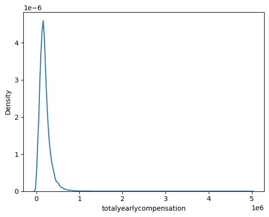

```python
# before transformation
sns.kdeplot(data=data, x="totalyearlycompensation")
```

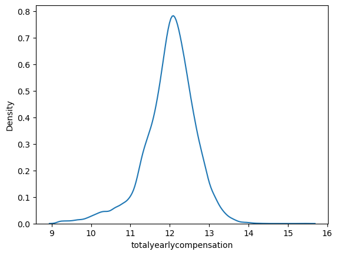

```python
# with transformation
sns.kdeplot(data=data, x=np.log(data.totalyearlycompensation))
```

We can see that with the log transformation, the output becomes much more normal whereas without the distribution it is skewed.

```python
print("MEAN:", np.mean(np.log(data.totalyearlycompensation)))
print("STD:", np.std((np.log(data.totalyearlycompensation))))
```

```
MEAN: 12.003546855460316
STD: 0.6572378258531245
```

#### 5.1.1 DataFrame before cleaning:

continuous variables:

```python
data.drop(columns='totalyearlycompensation').describe().T
```

|  | count | mean | std | min | 25% | 50% | 75% | max |
| --- | --- | --- | --- | --- | --- | --- | --- | --- |
| yearsofexperience | 21591.0 | 7.122042 | 5.847409 | 0.0 | 3.0 | 6.0 | 10.0 | 45.0 |
| yearsatcompany | 21591.0 | 2.703349 | 3.324903 | 0.0 | 0.0 | 2.0 | 4.0 | 40.0 |
| Masters_Degree | 21591.0 | 0.421194 | 0.493762 | 0.0 | 0.0 | 0.0 | 1.0 | 1.0 |
| Bachelors_Degree | 21591.0 | 0.506507 | 0.499969 | 0.0 | 0.0 | 1.0 | 1.0 | 1.0 |
| Doctorate_Degree | 21591.0 | 0.042796 | 0.202401 | 0.0 | 0.0 | 0.0 | 0.0 | 1.0 |
| ... | ... | ... | ... | ... | ... | ... | ... | ... |
| dmaid_820.0 | 21591.0 | 0.012042 | 0.109076 | 0.0 | 0.0 | 0.0 | 0.0 | 1.0 |
| dmaid_825.0 | 21591.0 | 0.010930 | 0.103978 | 0.0 | 0.0 | 0.0 | 0.0 | 1.0 |
| dmaid_855.0 | 21591.0 | 0.001204 | 0.034682 | 0.0 | 0.0 | 0.0 | 0.0 | 1.0 |
| dmaid_862.0 | 21591.0 | 0.002779 | 0.052644 | 0.0 | 0.0 | 0.0 | 0.0 | 1.0 |
| dmaid_other | 21591.0 | 0.011255 | 0.105492 | 0.0 | 0.0 | 0.0 | 0.0 | 1.0 |

106 rows × 8 columns

categorical variables:

```python
data_not_dummy = pd.read_csv("cleaned_before_dummies.csv")
```

```python
data_not_dummy.company.value_counts()
```

```
other         12718
amazon         2595
microsoft      1629
google         1319
facebook       1003
apple           608
oracle          404
ibm             366
intel           332
cisco           316
salesforce      301
Name: company, dtype: int64
```

```python
data_not_dummy.level.value_counts()
```

```
other                       13343
L4                           1908
L5                           1801
L3                           1355
L6                            929
L2                            572
Senior Software Engineer      484
L1                            387
L7                            303
IC4                           257
E5                            252
Name: level, dtype: int64
```

```python
data_not_dummy.title.value_counts()
```

```
Software Engineer               13700
Product Manager                  1453
other                            1216
Software Engineering Manager     1024
Data Scientist                    875
Hardware Engineer                 783
Technical Program Manager         635
Product Designer                  601
Management Consultant             450
Business Analyst                  445
Solution Architect                409
Name: title, dtype: int64
```

```python
data_not_dummy.tag.value_counts()
```

```
other                             7429
Full Stack                        3698
Distributed Systems (Back-End)    3296
API Development (Back-End)        2094
Web Development (Front-End)       1018
ML / AI                            986
Product                            896
Data                               831
DevOps                             487
Technical                          434
User Experience (UX)               422
Name: tag, dtype: int64
```

```python
data_not_dummy.gender.value_counts()
```

```
Male      17605
Female     3880
Other       106
Name: gender, dtype: int64
```

```python
data_not_dummy.dmaid.value_counts()
```

```
807.0    5710
0.0      4639
819.0    3546
501.0    1808
635.0     624
506.0     618
511.0     561
803.0     498
623.0     392
602.0     329
820.0     260
524.0     251
other     243
825.0     236
751.0     196
504.0     154
753.0     143
560.0     140
613.0     114
618.0      91
505.0      91
770.0      90
517.0      75
508.0      68
616.0      66
862.0      60
556.0      49
528.0      47
535.0      45
609.0      40
534.0      38
527.0      37
670.0      37
669.0      36
512.0      35
641.0      34
659.0      33
515.0      27
855.0      26
539.0      22
533.0      18
757.0      13
675.0      11
521.0      10
617.0      10
789.0      10
652.0      10
Name: dmaid, dtype: int64
```

#### 5.1.2 Data Cleaning:

We droped: * location and cityid since we used dmaid to account for location instead of the location column since it was more generalized and a bit broader. * Race and Education - these already existed as dummy variable columns in the dataframe * Timestampd, basesalary, stockgrantvalue, otherdetails, rowNumber, bonus since we did not see these columns as contibuting to the current salary

Other changes: * We converting the dmaid to a string since the value of a “zipcode” cannot be considered as a numerical value. * We dropped all values where gender, race, or education were null * We cleaned all values that were “messy” through case conversion, dropping certain characters (spaces, commas, periods, etc.)

See the code below:

```python
# Data Cleaning
# use dmaid for location predictor
data_cleaned = data.drop(columns = ["location", "timestamp", "basesalary", "stockgrantvalue", "otherdetails", "rowNumber", "bonus", "cityid"])
data_cleaned = data_cleaned.loc[data_cleaned.gender.notnull() & data_cleaned.Race.notnull() & data_cleaned.Education.notnull()]
data_cleaned = data_cleaned.drop(columns = ["Race", "Education"]) # alreadyy listed as dummy vars
data_cleaned.company = data_cleaned.company.str.lower()
data_cleaned.company = data_cleaned.company.str.replace(" ", "")
data_cleaned.company = data_cleaned.company.str.replace("-", "")
data_cleaned.company = data_cleaned.company.str.replace(",", "")
data_cleaned.company = data_cleaned.company.str.replace(".", "")
data_cleaned['dmaid'] = data_cleaned['dmaid'].astype(str)
```

The following columns were categorical” company, tag, title, level, dmaid. To account for the extremely high level of value counts, we selected the top 10 value counts from compnay, tag, title, and level. We could cinfidently do this since many of these values had value counts less than 10. In other words, if there was an extremely low value count in this column, we knew it would not contribute to the test accuracy of our model. We did keep many of the dmaid values though since including them all (above a very low threshold) was only 46 total new predictors.

```python
top_cmp_lst = data_cleaned.company.value_counts().index.to_list()[:10]
top_tag_lst = data_cleaned.tag.value_counts().index.to_list()[:10]
top_title_lst = data_cleaned.title.value_counts().index.to_list()[:10]
top_level_lst = data_cleaned.level.value_counts().index.to_list()[:10]
top_dmaid_lst = data_cleaned.dmaid.value_counts().index.to_list()[:46]
```

## 6 Exploratory data analysis

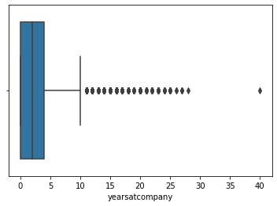

```python
# Visualize distribution of yearsatcompany
sns.boxplot(data=data, x="yearsatcompany")
```

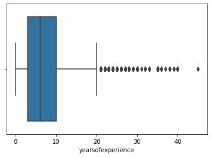

```python
# Visualize distribution of yearsofexperience
sns.boxplot(data=data, x="yearsofexperience")
```

```
(0.0, 1000000.0)
```

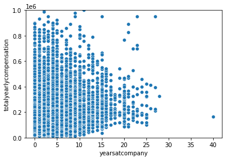

```python
# Visualize relationship between yearsatcompany and response
ax = sns.scatterplot(data=data, x = "yearsatcompany", y = "totalyearlycompensation")
ax.set_ylim(0, 1000000)
```

```
(0.0, 1000000.0)
```

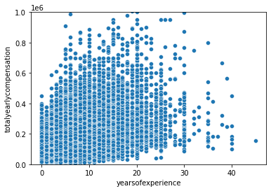

```python
# Visualize relationship between yearsofexperience and response
ax = sns.scatterplot(data=data, x = "yearsofexperience", y = "totalyearlycompensation")
ax.set_ylim(0, 1000000)
```

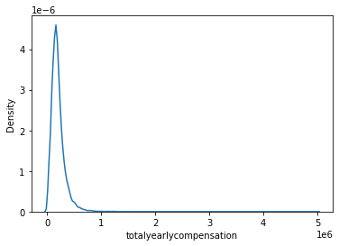

```python
# before transformation
sns.kdeplot(data=data, x="totalyearlycompensation")
```

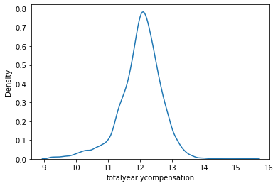

```python
# with transformation
sns.kdeplot(data=data, x=np.log(data.totalyearlycompensation))
```

- The first four graphs of this section didn’t provide any insights that helped with our models. We wanted to see whether any sort of transformation would have helped with our models, however the results of the graphs indicated that no transformations were needed.
- The last two graphs in this section helped us understand that a log transformation was helpful for our response variable. The data was very skewed to the right originally, and a log transformation helped it become more normal.

## 7 Approach

We optimized MAE for this prediction problem because there is no inherent risk in predicting a salary incorrectly. RMSE as a metric to optimize makes sense when an inaccurate prediction is dangerous, but this is not an issue when predicting STEM salaries.

Our problem did have some solutions in Kaggle. We used the best solutions to guide our approach to this problem: the best solution we found used random forests and boosting methods to optimize MAE, so we included these models in our problem. Another existing solution used a linear model and their MAE was extremely high (~1.9 trillion). This made it clear to us that there may have been some key outliers in our data that made it difficult for linear models to predict salary.

We did not use any additional code repositories.

## 8 Developing the model: Hyperparameter tuning

### 8.1 Lasso & Ridge

*By Charlie Lovett*

The process for developing Lasso and Ridge models is simple because there is only one hyperparameter to tune for each: the regularization constant alpha. Both processes were nearly identical:

I began by standardizing the predictors. This is important when using Lasso and Ridge because the algorithms penalize the coefficients of the predictors. If the predictors aren’t on the same scale, the penalization would be dominated by those that are on a larger scale.

For each model, I used a coarse search for alpha and a fine search for alpha. For Lasso, these ranges were $10**np.linspace(2,-3,50)*0.1$ and $10**np.linspace(-3,-2,100)$, respectively. For Ridge, these ranges were $10**np.linspace(10,-2,200)*0.5$ and $10**np.linspace(1.7,2.06,200)$, respectively.

The resulting alpha for Lasso was 0.001 and the alpha for Ridge was 85.06. With these values, the results were as follows:

Lasso Final MAE: “55359.5

Ridge Final MAE: 55394.6

### 8.2 Random Forest

*By Lainey Neild*

Next, I completed many iterative loops through arbitrarily set parameters. I started with the parameters from the stat303 notes for max_depth, max_leaf_nodes, and max_features and then continuously adjusted the ranges. After ~5 of these loops, I got a good sense of the range of each hyperparameter, which allowed me to conduct more effective Grid Searches with 5 folds.

My final iteration used this pramater grid:

n_estimators: [375], max_depth: [23, 24, 25, 26, 27], max_leaf_nodes:[3100, 3250, 3400], max_features: [20]

I got the following optimal paramters:

max_depth=25 max_leaf_nodes=3100

In this iteraction, I set max_features to 20 since I had already narrowed that hyperparamtere’s range enough through the previous iterations. I also was able to decide that max_depth and max_leaf_nodes had a narrow enoguh range and I could stop these wider parameter searches and move onto grid searches. I came to this conclusions since max_depth return the value in the middle of it’s range of a and although max_leaf_nodes return the lower bound of its range, I had already throughoutly tested max_leaf_nodes less than 3100.

Ultimately, I completed 2 GridSearchCV to optimize all the hyperparameters. The first extended the many iterations I took over a broad sense of each hyperparameter. This first GridSearch further narrowed the range, and then I conducted one more to finalize my hyperparameter values.

My final GridSearch used the followinf parameters:

n_estimators: [375], max_depth: [25, 26, 27, 28, 29], max_leaf_nodes:[32500, 3500, 3750], max_features: [18, 20, 22]

Althoguh this range seems quite narrow, I had already done sufficient range testing so I felt confident in the values I selected.

The final model: n_estimators=375 max_leaf_nodes=3500 max_depth=25 max_features=22

*Final MAE: $48,520*

### 8.3 AdaBoost

*By Jacob Muriel*

Before I started tuning the hyperparameters, I plotted a cross validated MAE for each value of the hyperparameters against the value itself, to get a better sense of how I should approach the hyperparemeter space. I then used those graphs to determine what hyperparemeter values I should put in my grid for the GridSearchCV. I got the resuld from the gridsearch, and decided to manually tune some of the values against a splitted version of the training data. Then, I included a final grid search once I had a better sense of the hyperparameter values that worked best.

Initial AdaBoost Search: - grid[‘n_estimators’] = [200] - grid[‘max_depth’] = [4, 8, 12, 16, 20, 24] - grid[‘learning_rate’] = [0.001, 0.01, 0.1, 1]

Final AdaBoost Search: - grid[‘n_estimators’] = [200] - grid[‘max_depth’] = [14, 18, 20] - grid[‘learning_rate’] = [0.05, 0.075, 0.1, 0.125, 1.15]

### 8.4 Gradient Boosting & XGBoost

*By Jack Troxel*

I used extremely similar processes to tune both Gradient Boosting and XGBoost. For both, I started with an extremely coarse gridsearch using RandomizedSearchCV based on the results of an exploration into each hyperparameter value versus the corresponding cross validation MAE. After that, I conducted I finer search using GridSearchCV. I continued to narrow in on finer and finer parameters until I found that the optimal parameters from these searches were actually increasing MAE on test data (due to overfitting). The searches that I conducted and the results that I achieved are seen below. As seen, I did not include n_estimators in any of my searches. Instead, I tuned n_estimators individually after deciding upon the other optimal hyperparameters.

Initial Gradient Boosting Search (RandomizedSearchCV): - grid[‘learning_rate’] = [0.0001, 0.001, 0.01,0.1, 1.0] - grid[‘max_depth’] = [5,6,7,8,9,10,11,12] - grid[‘subsample’] = [0.25, 0.5, 0.75, 1]

Gradient Boosting Optimal Hyperparameters (after multiple rounds of finer tuning): - learning_rate = 0.1 - subsample = 0.75 - max_depth = 6 - n_estimators = 450

*Gradient Boosting MAE on Test Data: 47,579*

Initial XGBoost Search (RandomizedSearchCV): - grid[‘max_depth’] = [3,4,5,6,7,8], - grid[‘learning_rate’] = [0.1,0.2,0.3], - grid[‘reg_lambda’] = [2, 10], - grid[‘gamma’] = [0, 10], - grid[‘subsample’] = [0.25,0.5,0.75,1]

XGBoost Optimal Hyperparameters (after multiple rounds of finer tuning): - max_depth = 6 - learning_rate = 0.08 - reg_lambda = 10 - gamma = 0 - subsample = 0.75 - n_estimators = 450

*XGBoost MAE on Test Data: 47,440*

## 9 Model Ensemble

*By Charlie Lovett*

### 9.1 Voting ensemble

The first ensemble model we chose to use was a voting ensemble with equal weights for each base model.

Voting Ensemble MAE: 48175.7

### 9.2 Stacking ensemble

We made three stacking ensemble models, each with a different metamodel. The metamodels we used were Linear Regression, Lasso, and MARS.

Linear Regression metamodel MAE: 47109.3  
Lasso metamodel MAE: 47093.6  
Mars metamodel MAE: 47157.2

## 10 Limitations of the model with regard to prediction

We are fairly confident in our chosen hyperparameters. While we did have a large dataset with a large amount of dummy variables, we still were able to perform effective grid searches to gauge the hyperparameter space with regards to our model’s accuracy. That said, we obviously did not check every single combination of hyperparameters so it is definitely possible that there are better selections, and given some more time and computational power we likely could have achieved marginally better results. Additionally, it should not be too difficult for the stakeholders to collect relevant data relating to the predictors in the model. Individual students and employees should be aware of their own identities and the characteristics of their jobs (or prospective jobs) which is all they would need to use the model, and employers should have all the same information on their own employees to be used in the same way. It might be a bit more difficult for universities to track where their students typically work after studying or where their current students are likely to go, though they probably do have some of the relevant information on hand. The model may become obsolete by the year, in which case it could simply be updated by being trained on a new dataset with updated salaries and other relevant information. Once it’s updated, stakeholders should be able to use it right away to decide how to proceed with their future.

## Individual contribution

| Team member | Individual Model | Work other than individual model | Details of work other than individual model |
| --- | --- | --- | --- |
| Charlie Lovett | Lasso & Ridge | Data cleaning and Model Ensembling | Helped to limit count of categorical observations. Led the development of ensembeled models. |
| Jacob Muriel | AdaBoost | Ensembling | Led original data cleaning and assisted Charlie with ensembling. |
| Lainey Neild | Random forest | EDA and Data Preparation | Conducted initial EDA and assisted in data preparation process. |
| Jack Troxel | XGBoost & Gradient Boosting | EDA and Presentation | Helped with initial EDA and created presentation for final project. |